# Course Project No. 4

Cuachon, Guzman

May 25, 2019

This is our first Markdown document.

Project No. 4 for Stat 197 (Data Science)

# Setting Directory

```r
setwd("C:/Users/CLIENT/Desktop")
```

# Reading the datasets

```r
NEI <- readRDS("summarySCC_PM25.rds")
SCC <- readRDS("Source_Classification_Code.rds")
```

# Exploring the PM2.5 Emissions Data

```r
head(NEI)
```

```
##     fips      SCC Pollutant Emissions  type year
## 4  09001 10100401  PM25-PRI    15.714 POINT 1999
## 8  09001 10100404  PM25-PRI   234.178 POINT 1999
## 12 09001 10100501  PM25-PRI     0.128 POINT 1999
## 16 09001 10200401  PM25-PRI     2.036 POINT 1999
## 20 09001 10200504  PM25-PRI     0.388 POINT 1999
## 24 09001 10200602  PM25-PRI     1.490 POINT 1999
```

```r
names(NEI)
```

```
## [1] "fips"      "SCC"       "Pollutant" "Emissions" "type"      "year"
```

# Exploring the Source Classification Code Table Data

```r
head(SCC)
```

```
##        SCC Data.Category
## 1 10100101         Point
## 2 10100102         Point
## 3 10100201         Point
## 4 10100202         Point
## 5 10100203         Point
## 6 10100204         Point
##                                                                   Short.Name
## 1                   Ext Comb /Electric Gen /Anthracite Coal /Pulverized Coal
## 2 Ext Comb /Electric Gen /Anthracite Coal /Traveling Grate (Overfeed) Stoker
## 3       Ext Comb /Electric Gen /Bituminous Coal /Pulverized Coal: Wet Bottom
## 4       Ext Comb /Electric Gen /Bituminous Coal /Pulverized Coal: Dry Bottom
## 5                   Ext Comb /Electric Gen /Bituminous Coal /Cyclone Furnace
## 6                   Ext Comb /Electric Gen /Bituminous Coal /Spreader Stoker
##                                EI.Sector Option.Group Option.Set
```

[output cut: 34 more lines]

```r
names(SCC)
```

```
##  [1] "SCC"                 "Data.Category"       "Short.Name"
##  [4] "EI.Sector"           "Option.Group"        "Option.Set"
##  [7] "SCC.Level.One"       "SCC.Level.Two"       "SCC.Level.Three"
## [10] "SCC.Level.Four"      "Map.To"              "Last.Inventory.Year"
## [13] "Created_Date"        "Revised_Date"        "Usage.Notes"
```

# Questions

## Question 1: Have total emissions from PM2.5 decreased in the United States from 1999 to 2008? Using the base plotting system, make a plot showing the total PM2.5 emission from all sources for each of the years 1999, 2002, 2005, and 2008.

### Codes and plot for Question 1

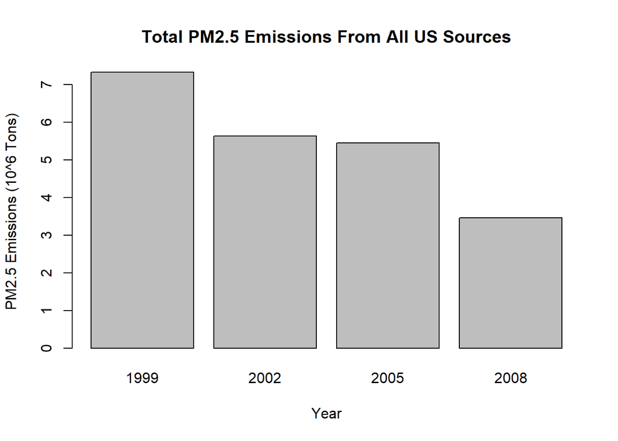

```r
total <- aggregate(Emissions ~ year, NEI, sum)
barplot(
    (total$Emissions)/10^6,
    names.arg=total$year,
    xlab="Year",
    ylab="PM2.5 Emissions (10^6 Tons)",
    main="Total PM2.5 Emissions From All US Sources"
)
```

## Question 2: Have total emissions from PM2.5 decreased in the Baltimore City, Maryland (fips==“24510”) from 1999 to 2008? Use the base plotting system to make a plot answering this question.

### Codes and plot for Question 2

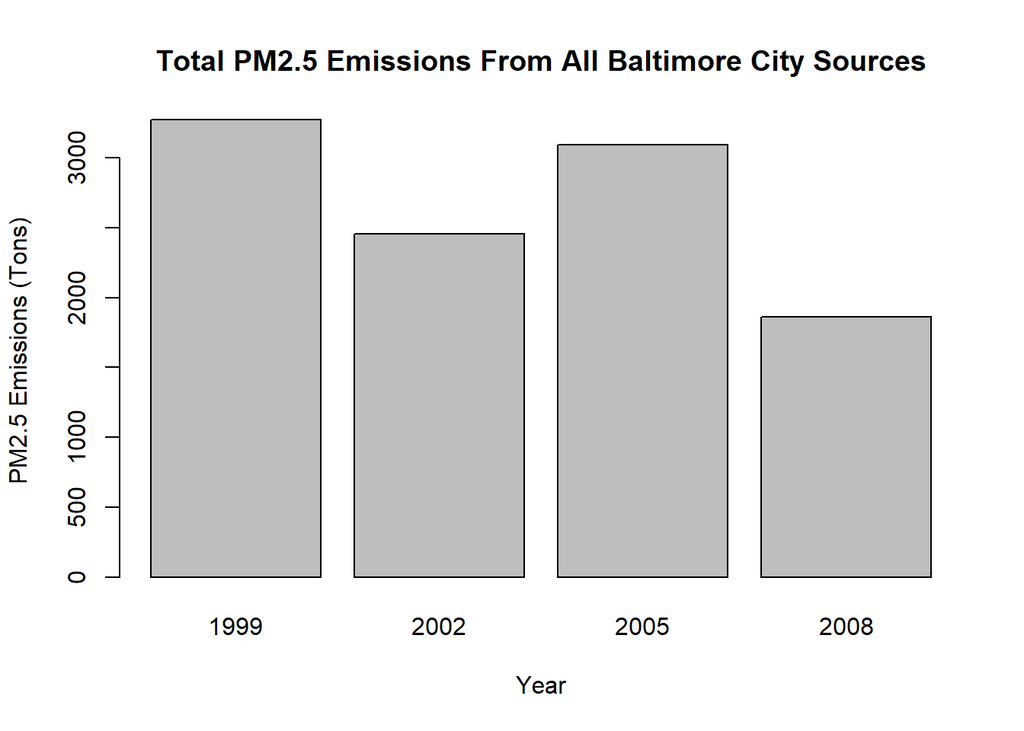

```r
baltimoreNEI <- NEI[NEI$fips=="24510",]
aggTotalsBaltimore <- aggregate(Emissions ~ year, baltimoreNEI,sum)
barplot(
    aggTotalsBaltimore$Emissions,
    names.arg=aggTotalsBaltimore$year,
    xlab="Year",
    ylab="PM2.5 Emissions (Tons)",
    main="Total PM2.5 Emissions From All Baltimore City Sources"
)
```

## Question 3: Of the four types of sources indicated by the type (point, nonpoint, onroad, nonroad) variable, which of these four sources have seen decreases in emissions from 1999-2008 for Baltimore City? Which have seen increases in emissions from 1999-2008? Use the ggplot2 plotting system to make a plot answer this question.

### Codes and plot for Question 3

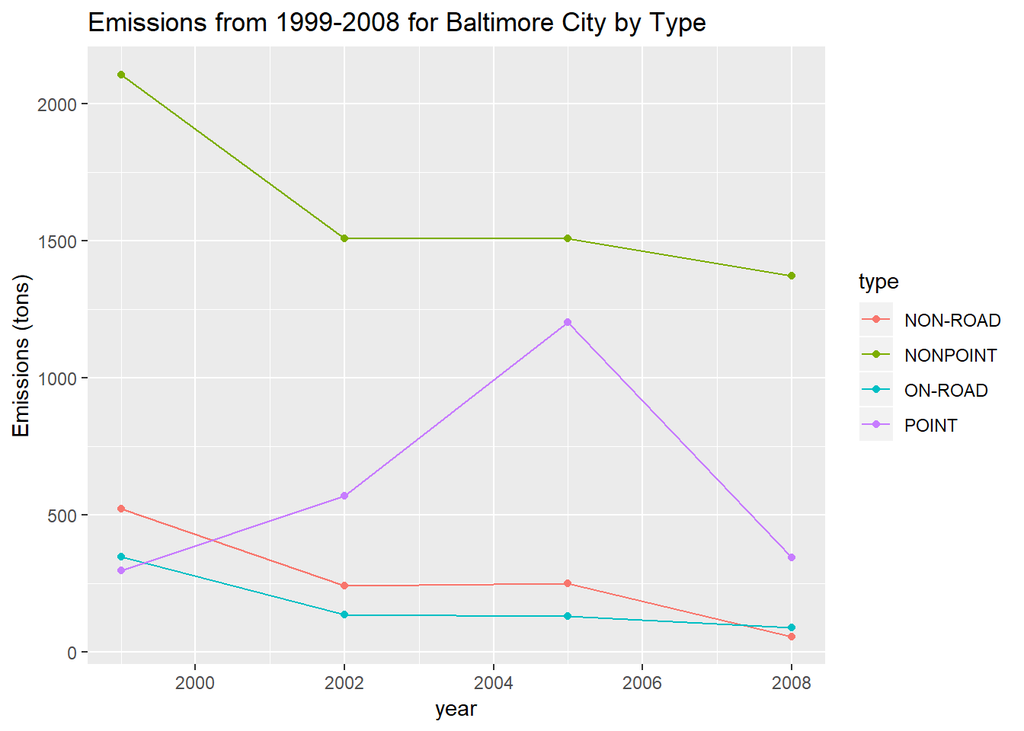

```r
#Aggregating and naming the columns
balem <-aggregate(NEI$Emissions,by=list(NEI$year, NEI$fips=='24510',NEI$type),sum)
names(balem) <-c('year','Bal','type','Emissions')
balem<-balem[balem$Bal==TRUE,]

#Plotting
library(ggplot2)
qplot(year,Emissions,data=balem, geom=c('line','point'), color=type,
      main='Emissions from 1999-2008 for Baltimore City by Type', ylab='Emissions (tons)')
```

## Question 4: Across the United States, how have emissions from coal combustion-related sources changed from 1999-2008?

### Codes and plot for Question 4

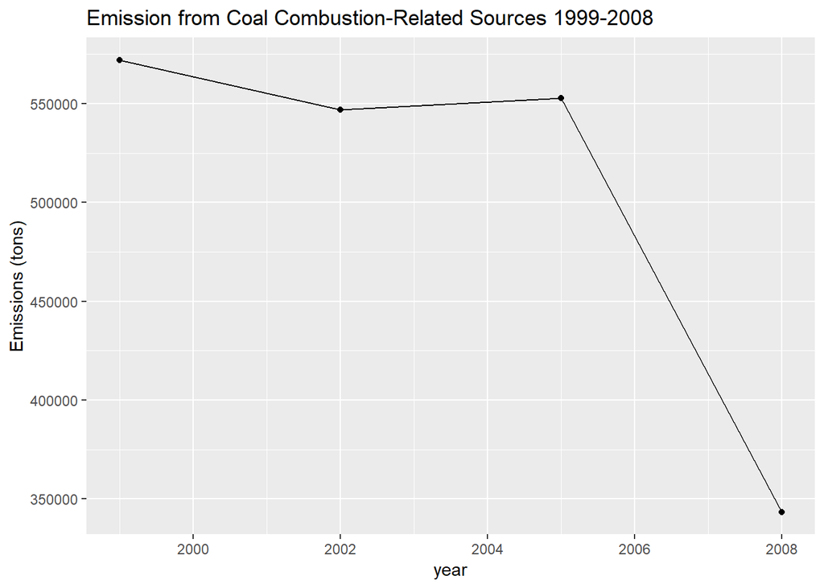

```r
#Getting the SCC for coal-related combustions
i<-grep('Coal',SCC$EI.Sector,ignore.case = TRUE)
index <-SCC[i,]$SCC

#Aggregating and naming the columns
coalem <-aggregate(NEI$Emissions,by=list(NEI$year, NEI$SCC %in% index),sum)
names(coalem) <-c('year','Coal','Emissions')
coal.em<-coalem[coalem$Coal==TRUE,]

#Plotting
library(ggplot2)
qplot(year,Emissions,data=coal.em, geom=c('line','point'),
      main='Emission from Coal Combustion-Related Sources 1999-2008', ylab='Emissions (tons)')
```

## Question 5: How have emissions from motor vehicle sources changed from 1999-2008 in Baltimore City?

### Codes and plot for Question 5

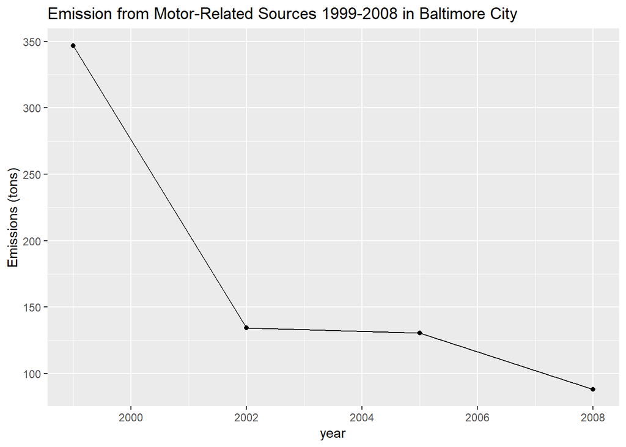

```r
motorem <-aggregate(NEI$Emissions,
                    by=list(NEI$year, NEI$fips=='24510', NEI$type=='ON-ROAD'),sum)
names(motorem) <-c('year','type','Bal','Emissions')
motor.em<-motorem[motorem$type==TRUE & motorem$Bal==TRUE,]

#Plotting
library(ggplot2)
qplot(year,Emissions,data=motor.em, geom=c('line','point'),
      main='Emission from Motor-Related Sources 1999-2008 in Baltimore City',
      ylab='Emissions (tons)')
```

## Question 6: Compare emissions from motor vehicle sources in Baltimore City with emissions from motor vehicle sources in Los Angeles County, California (fips == “06037”).Which city has seen greater changes over time in motor vehicle emmissions?

### Codes and plot for Question 6

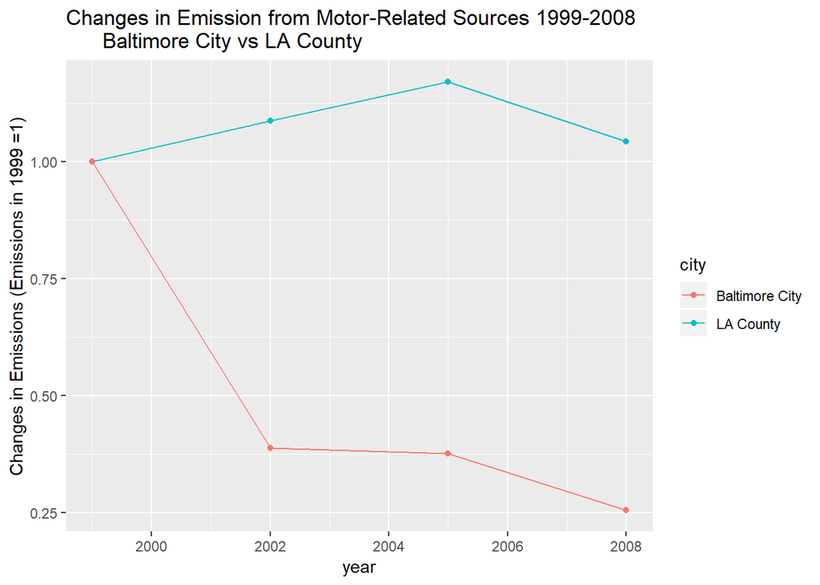

```r
motor <-aggregate(NEI$Emissions,
                    by=list(NEI$year, NEI$type=='ON-ROAD',NEI$fips),sum)
names(motor) <-c('year','type','fips','Emissions')
motorem.city<-motor[motor$type==TRUE &
                     (motor$fips=='24510'|motor$fips=='06037'),]
motorem.city$city <-ifelse(motorem.city$fips=='24510','Baltimore City','LA County')


#Create changes variable with the baseline being Emissions in 1999 for both cities

baseline<-motorem.city[motorem.city$year==1999,]
motorem.city$baseline<-ifelse(motorem.city$fips=='24510',baseline[baseline$fips=='24510',4],
                         baseline[baseline$fips=='06037',4])
motorem.city$changes<-motorem.city$Emissions/motorem.city$baseline

#Plot
library(ggplot2)
qplot(year,changes,data=motorem.city, geom=c('line','point'),
      main='Changes in Emission from Motor-Related Sources 1999-2008
      Baltimore City vs LA County',
      color=city, ylab='Changes in Emissions (Emissions in 1999 =1)')
```